# 🧼 Notebook 4 - Fine Tuning XCEPTION

# 1.Chargement du modèle initial

On commence par charger le modèle entraîné initialement (avec la tête personnalisée) que l’on a sauvegardé dans le dossier `modeles`.

Ce modèle a la base Xception gelée.

```python
from tensorflow.keras.models import load_model
import os


model_path = '/Users/Thomas/Desktop/X_RAY/modeles/model_initial.keras'
if not os.path.exists(model_path):
    print(f"ERREUR: Le fichier modèle {model_path} n'existe pas!")
    exit()

print(f"Chargement du modèle depuis: {model_path}")

try:
    model = load_model(model_path, compile=False)
    print("Modèle initial chargé.")
except Exception as e:
    print(f"Erreur lors du chargement du modèle: {str(e)}")
    model = None

if model is None:
    print("Impossible de charger le modèle. Veuillez vérifier le fichier.")
else:
    print(f"Modèle chargé avec succès, nombre de couches : {len(model.layers)}")
```

```
Chargement du modèle depuis: /Users/Thomas/Desktop/X_RAY/modeles/model_initial.keras
Modèle initial chargé.
Modèle chargé avec succès, nombre de couches : 141
Modèle initial chargé.
Modèle chargé avec succès, nombre de couches : 141
```

## 2. Débloquer les couches pour le fine-tuning

Pour le fine-tuning, nous devons rendre certaines couches du modèle de base Xception entraînables. Nous allons débloquer progressivement les couches profondes qui sont responsables des caractéristiques de haut niveau.

```python
from tensorflow.keras.applications import Xception
from tensorflow.keras.layers import GlobalAveragePooling2D, Dense, Dropout, BatchNormalization
from tensorflow.keras.models import Model
from tensorflow.keras.optimizers import Adam
import tensorflow as tf


base_model.trainable = True


fine_tune_at = len(base_model.layers) - 12
for layer in base_model.layers[:fine_tune_at]:
    layer.trainable = False


trainable_layers = [layer.name for layer in base_model.layers[fine_tune_at:]]
print(f"Nombre de couches débloquées pour fine-tuning : {len(trainable_layers)}")
print("Couches débloquées:", ", ".join(trainable_layers))


model.compile(
    optimizer=Adam(learning_rate=2e-5),
    loss='binary_crossentropy',
    metrics=[
        'accuracy',
        tf.keras.metrics.Precision(name='precision')
    ]
)
print("Modèle recompilé avec un learning rate de 2e-5 pour le fine-tuning")


trainable_params = sum([tf.keras.backend.count_params(w) for w in model.trainable_weights])
non_trainable_params = sum([tf.keras.backend.count_params(w) for w in model.non_trainable_weights])
print(f"\nParamètres entraînables: {trainable_params:,}")
print(f"Paramètres non-entraînables: {non_trainable_params:,}")
print(f"Total des paramètres: {trainable_params + non_trainable_params:,}")
```

```
Nombre de couches débloquées pour fine-tuning : 12
Couches débloquées: block13_sepconv2, block13_sepconv2_bn, conv2d_3, block13_pool, batch_normalization_3, add_11, block14_sepconv1, block14_sepconv1_bn, block14_sepconv1_act, block14_sepconv2, block14_sepconv2_bn, block14_sepconv2_act
Modèle recompilé avec un learning rate de 2e-5 pour le fine-tuning

Paramètres entraînables: 1,120,257
Paramètres non-entraînables: 20,866,856
Total des paramètres: 21,987,113
```

## 3. Entraînement du modèle fine-tuné

Nous allons continuer l'entraînement à partir de l'époque 5 pour quelques époques supplémentaires. Le fine-tuning nécessite généralement moins d'époques que l'entraînement initial. Nous utilisons un learning rate plus faible et des callbacks pour éviter le surapprentissage.

Callbacks :

- EarlyStopping : Arrête l'entraînement si la perte en validation ne s'améliore pas pendant un certain nombre d'époques (patience). Restaure les meilleurs poids pour éviter le surapprentissage.
- ReduceLROnPlateau : Réduit le learning rate par un facteur si la perte en validation atteint un plateau pendant un certain nombre d'époques (patience). Garantit que le learning rate ne descend pas en dessous d'un seuil minimum.
- ModelCheckpoint : Sauvegarde le modèle avec la meilleure perte en validation pendant l'entraînement.

```python
from tensorflow.keras.callbacks import EarlyStopping, ReduceLROnPlateau, ModelCheckpoint


callbacks = [
    # Arrêt anticipé si le modèle ne s'améliore plus
    EarlyStopping(
        monitor='val_loss',
        patience=4,              # Plus patient pour éviter d'arrêter trop tôt
        restore_best_weights=True,
        verbose=1
    ),
    # Réduction du learning rate si plateau
    ReduceLROnPlateau(
        monitor='val_loss',
        factor=0.5,              # Réduction plus douce du learning rate
        patience=2,
        min_lr=1e-7,
        verbose=1
    ),
    # Sauvegarde du meilleur modèle
    ModelCheckpoint(
        'modeles/model_fine_tuned_best.keras',
        monitor='val_loss',
        save_best_only=True,
        verbose=1
    )
]


initial_epoch = 5  # Continuer à partir de l'époque 5 (après l'entraînement initial)
fine_tune_epochs = 5  # Nombre d'époques supplémentaires pour le fine-tuning
total_epochs = initial_epoch + fine_tune_epochs

# Entraîner le modèle
print(f"\nDébut du fine-tuning pour {fine_tune_epochs} époques supplémentaires...")
history_fine = model.fit(
    train_ds,
    validation_data=val_ds,
    epochs=total_epochs,
    initial_epoch=initial_epoch,
    callbacks=callbacks
)
```

```
Début du fine-tuning pour 5 époques supplémentaires...
154/154 ━━━━━━━━━━━━━━━━━━━━ 0s 3s/step - accuracy: 0.9709 - loss: 0.0763 - precision: 0.9697
Epoch 6: val_loss improved from inf to 0.12206, saving model to modeles/model_fine_tuned_best.keras

Epoch 6: val_loss improved from inf to 0.12206, saving model to modeles/model_fine_tuned_best.keras
154/154 ━━━━━━━━━━━━━━━━━━━━ 499s 3s/step - accuracy: 0.9709 - loss: 0.0763 - precision: 0.9698 - val_accuracy: 0.9581 - val_loss: 0.1221 - val_precision: 0.9634 - learning_rate: 2.0000e-05
154/154 ━━━━━━━━━━━━━━━━━━━━ 499s 3s/step - accuracy: 0.9709 - loss: 0.0763 - precision: 0.9698 - val_accuracy: 0.9581 - val_loss: 0.1221 - val_precision: 0.9634 - learning_rate: 2.0000e-05
154/154 ━━━━━━━━━━━━━━━━━━━━ 0s 3s/step - accuracy: 0.9766 - loss: 0.0622 - precision: 0.9693
Epoch 7: val_loss improved from 0.12206 to 0.12117, saving model to modeles/model_fine_tuned_best.keras

Epoch 7: val_loss improved from 0.12206 to 0.12117, saving model to modeles/model_fine_tuned_best.keras
154/154 ━━━━━━━━━━━━━━━━━━━━ 492s 3s/step - accuracy: 0.9766 - loss: 0.0622 - precision: 0.9694 - val_accuracy: 0.9610 - val_loss: 0.1212 - val_precision: 0.9654 - learning_rate: 2.0000e-05
154/154 ━━━━━━━━━━━━━━━━━━━━ 492s 3s/step - accuracy: 0.9766 - loss: 0.0622 - precision: 0.9694 - val_accuracy: 0.9610 - val_loss: 0.1212 - val_precision: 0.9654 - learning_rate: 2.0000e-05
154/154 ━━━━━━━━━━━━━━━━━━━━ 0s 3s/step - accuracy: 0.9759 - loss: 0.0651 - precision: 0.9738
Epoch 8: val_loss did not improve from 0.12117
154/154 ━━━━━━━━━━━━━━━━━━━━ 487s 3s/step - accuracy: 0.9759 - loss: 0.0651 - precision: 0.9739 - val_accuracy: 0.9619 - val_loss: 0.1221 - val_precision: 0.9672 - learning_rate: 2.0000e-05

Epoch 8: val_loss did not improve from 0.12117
154/154 ━━━━━━━━━━━━━━━━━━━━ 487s 3s/step - accuracy: 0.9759 - loss: 0.0651 - precision: 0.9739 - val_accuracy: 0.9619 - val_loss: 0.1221 - val_precision: 0.9672 - learning_rate: 2.0000e-05
154/154 ━━━━━━━━━━━━━━━━━━━━ 0s 3s/step - accuracy: 0.9795 - loss: 0.0576 - precision: 0.9791
Epoch 9: ReduceLROnPlateau reducing learning rate to 9.999999747378752e-06.

Epoch 9: val_loss did not improve from 0.12117
154/154 ━━━━━━━━━━━━━━━━━━━━ 484s 3s/step - accuracy: 0.9795 - loss: 0.0576 - precision: 0.9791 - val_accuracy: 0.9600 - val_loss: 0.1217 - val_precision: 0.9635 - learning_rate: 2.0000e-05

Epoch 9: ReduceLROnPlateau reducing learning rate to 9.999999747378752e-06.

Epoch 9: val_loss did not improve from 0.12117
154/154 ━━━━━━━━━━━━━━━━━━━━ 484s 3s/step - accuracy: 0.9795 - loss: 0.0576 - precision: 0.9791 - val_accuracy: 0.9600 - val_loss: 0.1217 - val_precision: 0.9635 - learning_rate: 2.0000e-05
154/154 ━━━━━━━━━━━━━━━━━━━━ 0s 3s/step - accuracy: 0.9811 - loss: 0.0510 - precision: 0.9788
Epoch 10: val_loss did not improve from 0.12117
154/154 ━━━━━━━━━━━━━━━━━━━━ 484s 3s/step - accuracy: 0.9811 - loss: 0.0510 - precision: 0.9788 - val_accuracy: 0.9610 - val_loss: 0.1230 - val_precision: 0.9636 - learning_rate: 1.0000e-05
Restoring model weights from the end of the best epoch: 7.

Epoch 10: val_loss did not improve from 0.12117
154/154 ━━━━━━━━━━━━━━━━━━━━ 484s 3s/step - accuracy: 0.9811 - loss: 0.0510 - precision: 0.9788 - val_accuracy: 0.9610 - val_loss: 0.1230 - val_precision: 0.9636 - learning_rate: 1.0000e-05
Restoring model weights from the end of the best epoch: 7.
```

# 4. Visualisation des courbes d’apprentissage détaillées

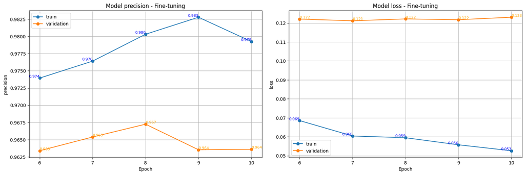

```python
import matplotlib.pyplot as plt

def plot_training_curves_with_values(history):

    available_metrics = [m for m in ['precision', 'loss'] if m in history.history]

    plt.figure(figsize=(16, 10))
    for i, metric in enumerate(available_metrics):
        plt.subplot(2, 2, i+1)
        train_values = history.history[metric]
        val_key = 'val_' + metric
        val_values = history.history[val_key] if val_key in history.history else []

        epochs_int = list(range(6, 6 + len(train_values)))

        plt.plot(epochs_int, train_values, label='train', marker='o')
        if val_values:
            plt.plot(epochs_int, val_values, label='validation', marker='o')


        for x, y in zip(epochs_int, train_values):
            plt.text(x, y, f'{y:.3f}', fontsize=8, color='blue', ha='right', va='bottom')
        for x, y in zip(epochs_int, val_values):
            plt.text(x, y, f'{y:.3f}', fontsize=8, color='orange', ha='left', va='bottom')

        plt.title(f'Model {metric} - Fine-tuning')
        plt.xlabel('Epoch')
        plt.ylabel(metric)
        plt.legend()
        plt.grid(True)

        ax = plt.gca()
        ax.set_xticks(epochs_int)
        ax.set_xticklabels([str(e) for e in epochs_int])

    plt.tight_layout()
    plt.show()


plot_training_curves_with_values(history_fine)

if 'lr' in history_fine.history:
    plt.figure(figsize=(10, 6))

    epochs_int = list(range(6, 6 + len(history_fine.history['lr'])))
    plt.plot(epochs_int, history_fine.history['lr'], marker='o')

    for x, y in zip(epochs_int, history_fine.history['lr']):
        plt.text(x, y, f'{y:.2e}', fontsize=8, color='blue', ha='center', va='bottom')

    plt.title('Évolution du Learning Rate')
    plt.xlabel('Epoch')
    plt.ylabel('Learning Rate')

    plt.xticks(epochs_int)
    plt.gca().set_xticklabels([str(e) for e in epochs_int])

    plt.yscale('log')
    plt.grid(True)
    plt.show()
```

## 📊 Analyse des courbes de précision et de loss du modèle

### 📈 Courbe de précision :

Train : Augmente globalement de 0.974 à 0.983 entre l’époque 6 et 9, puis légère baisse à 0.979 à l’époque 10.

Validation : Relativement stable, fluctue entre 0.963 et 0.967.

💡 Analyse :

Le modèle continue d'apprendre sur les données d'entraînement (hausse de la précision).

Mais la précision de validation plafonne, ce qui indique un début de surapprentissage (overfitting) dès l’époque 9-10.

### 📉 Courbe de loss :

Train : Diminue régulièrement (de 0.069 à 0.053), ce qui montre que le modèle s'ajuste bien.

Validation : Stable autour de 0.121–0.123

💡 Conclusion :

Le gap entre perte train/validation indique que le modèle surapprends sur les données d’entraînement à partir de l’époque 9.

### 5. Matrice de Confusion et Courbe ROC pour le Modèle Fine-Tuné

Visualisons la matrice de confusion pour évaluer les performances du modèle sur le jeu de test. Cette représentation nous permet de voir la distribution des prédictions correctes et incorrectes.

```
33/33 ━━━━━━━━━━━━━━━━━━━━ 86s 3s/step
33/33 ━━━━━━━━━━━━━━━━━━━━ 86s 3s/step
```

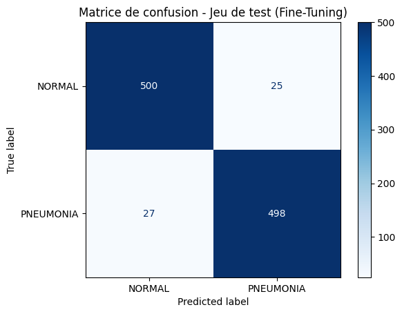

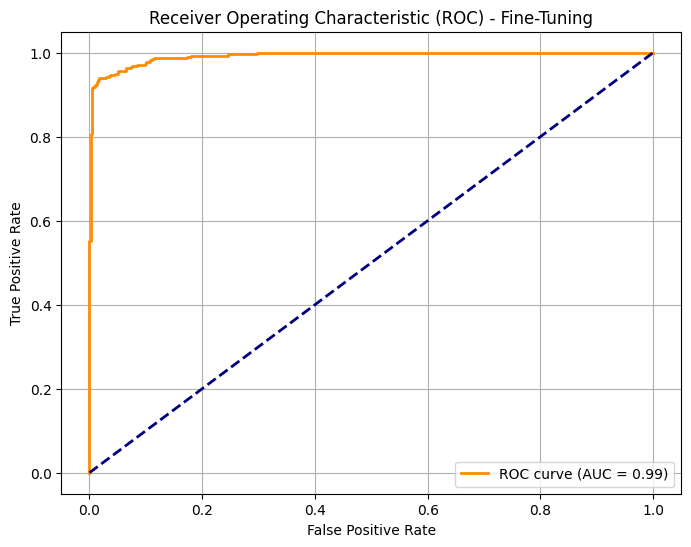

```python
import numpy as np
from sklearn.metrics import confusion_matrix, ConfusionMatrixDisplay, roc_curve, auc
import matplotlib.pyplot as plt


# Prédictions sur le dataset test (probabilités)
y_pred_prob = model.predict(test_ds)
# Binarisation avec seuil 0.5
y_pred = (y_pred_prob > 0.5).astype(int).flatten()

# Extraction des vraies étiquettes (one-hot vers entiers)
y_true = np.concatenate([labels.numpy() for _, labels in test_ds], axis=0)

# Matrice de confusion
cm = confusion_matrix(y_true, y_pred)
disp = ConfusionMatrixDisplay(confusion_matrix=cm, display_labels=class_names)
disp.plot(cmap=plt.cm.Blues)
plt.title("Matrice de confusion - Jeu de test (Fine-Tuning)")
plt.show()

# Courbe ROC
fpr, tpr, _ = roc_curve(y_true, y_pred_prob)
roc_auc = auc(fpr, tpr)

plt.figure(figsize=(8, 6))
plt.plot(fpr, tpr, color='darkorange', lw=2, label=f'ROC curve (AUC = {roc_auc:.2f})')
plt.plot([0, 1], [0, 1], color='navy', lw=2, linestyle='--')
plt.xlabel('False Positive Rate')
plt.ylabel('True Positive Rate')
plt.title('Receiver Operating Characteristic (ROC) - Fine-Tuning')
plt.legend(loc="lower right")
plt.grid(True)
plt.show()
```

### 🧮 Matrice de Confusion - Jeu de test (Fine-Tuning)

Métriques dérivées :

Précision pour PNEUMONIA = 498 / (498 + 25) = 0.952

Recall pour PNEUMONIA = 498 / (498 + 27) = 0.949

F1-Score pour PNEUMONIA ≈ 0.950

💡 Interprétation :

Le modèle confond encore 25 NORMAL et 27 PNEUMONIA, mais c’est peu par rapport à la taille totale.

La performance est très équilibrée sur les deux classes → pas de biais marqué.

### 📊Courbe ROC - Fine-Tuning

La courbe ROC est proche de l’angle supérieur gauche (parfait).

L’AUC = 0.99 est excellent, indiquant que le modèle discrimine très bien entre les deux classes.

💡 Analyse :

Même si la précision sur validation est stable, le modèle reste robuste en termes de classification binaire.

Cela suggère que le modèle est fiable pour une mise en production, avec éventuellement une régularisation à considérer pour éviter l’overfitting.

## 6. Sauvegarde et évaluation du modèle fine-tuné

```python
fine_tuned_model_path = 'modeles/model_fine_tuned.keras'
model.save(fine_tuned_model_path)
print(f"Modèle fine-tuné sauvegardé à: {fine_tuned_model_path}")

print("\nÉvaluation du modèle fine-tuné sur les données de test:")
test_results = model.evaluate(test_ds, verbose=1)

print("\nRésultats sur les données de test:")
for name, value in zip(model.metrics_names, test_results):
    print(f"{name}: {value:.4f}")
```

```
Modèle fine-tuné sauvegardé à: modeles/model_fine_tuned.keras

Évaluation du modèle fine-tuné sur les données de test:
33/33 ━━━━━━━━━━━━━━━━━━━━ 85s 3s/step - accuracy: 0.9389 - loss: 0.1342 - precision: 0.4564
33/33 ━━━━━━━━━━━━━━━━━━━━ 85s 3s/step - accuracy: 0.9389 - loss: 0.1342 - precision: 0.4564

Résultats sur les données de test:
loss: 0.1177
compile_metrics: 0.9505

Résultats sur les données de test:
loss: 0.1177
compile_metrics: 0.9505
```

```
--- Chargement du modèle fine-tuné pour l'analyse Grad-CAM ---
Modèle chargé depuis: modeles/model_fine_tuned.keras
Image PNEUMONIA sélectionnée : dataset/test/PNEUMONIA\person36_bacteria_182.jpeg
Image NORMAL sélectionnée : dataset/test/NORMAL\NORMAL2-IM-1177-0001.jpeg

--- Analyse d'une image avec pneumonie ---
Modèle chargé depuis: modeles/model_fine_tuned.keras
Image PNEUMONIA sélectionnée : dataset/test/PNEUMONIA\person36_bacteria_182.jpeg
Image NORMAL sélectionnée : dataset/test/NORMAL\NORMAL2-IM-1177-0001.jpeg

--- Analyse d'une image avec pneumonie ---
1/1 ━━━━━━━━━━━━━━━━━━━━ 1s 1s/step
1/1 ━━━━━━━━━━━━━━━━━━━━ 1s 1s/step
Image : person36_bacteria_182.jpeg
Prédiction : PNEUMONIA avec une probabilité de 99.73%
Image : person36_bacteria_182.jpeg
Prédiction : PNEUMONIA avec une probabilité de 99.73%
```

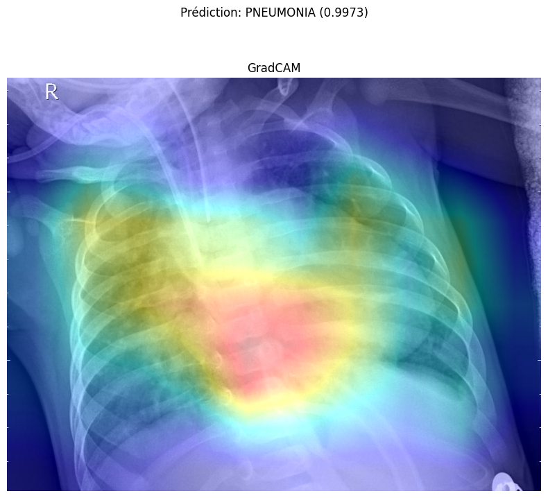

```
--- Analyse d'une image normale ---
1/1 ━━━━━━━━━━━━━━━━━━━━ 0s 115ms/step
1/1 ━━━━━━━━━━━━━━━━━━━━ 0s 115ms/step
Image : NORMAL2-IM-1177-0001.jpeg
Prédiction : NORMAL avec une probabilité de 0.03%
Image : NORMAL2-IM-1177-0001.jpeg
Prédiction : NORMAL avec une probabilité de 0.03%
```

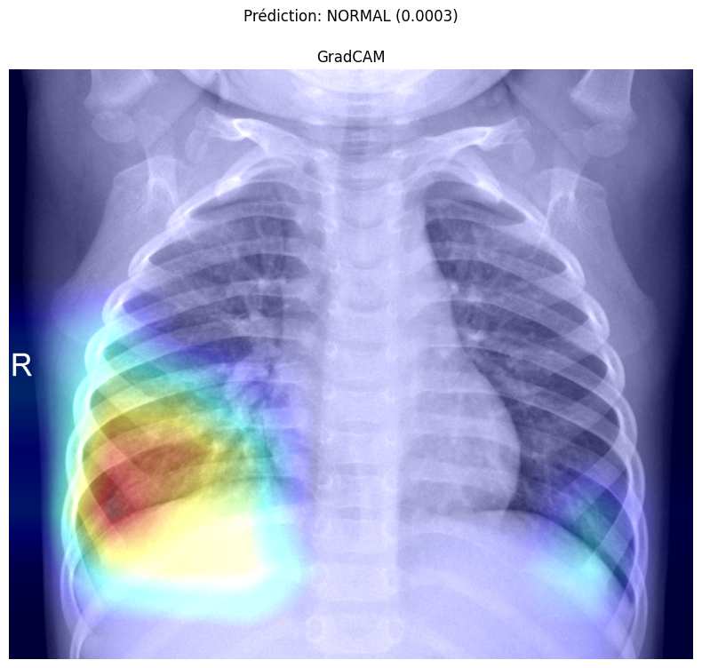

```python
import os
import random
import tensorflow as tf
import numpy as np
import matplotlib.pyplot as plt
import cv2
from tensorflow.keras.preprocessing import image
from IPython.display import display, Image as IPImage

def get_img_array(img_path, size):
    img = image.load_img(img_path, target_size=size)
    array = image.img_to_array(img)
    array = np.expand_dims(array, axis=0)
    return tf.keras.applications.xception.preprocess_input(array)

def make_gradcam_heatmap(img_array, model, last_conv_layer_name, pred_index=None):
    grad_model = tf.keras.models.Model(
        [model.inputs],
        [model.get_layer(last_conv_layer_name).output, model.output]
    )
    with tf.GradientTape() as tape:
        conv_outputs, predictions = grad_model(img_array)
        if pred_index is None:
            pred_index = tf.argmax(predictions[0])
        class_channel = predictions[:, pred_index]

    grads = tape.gradient(class_channel, conv_outputs)
    pooled_grads = tf.reduce_mean(grads, axis=(0, 1, 2))
    conv_outputs = conv_outputs[0]
    heatmap = conv_outputs @ pooled_grads[..., tf.newaxis]
    heatmap = tf.squeeze(heatmap)
    heatmap = tf.maximum(heatmap, 0) / tf.math.reduce_max(heatmap)
    return heatmap.numpy()

def display_gradcam(img_path, heatmap, pred_class=None, pred_value=None, alpha=0.4):
    img = cv2.imread(img_path)
    heatmap_resized = cv2.resize(heatmap, (img.shape[1], img.shape[0]))
    heatmap_uint8 = np.uint8(255 * heatmap_resized)
    heatmap_color = cv2.applyColorMap(heatmap_uint8, cv2.COLORMAP_JET)
    superimposed_img = heatmap_color * alpha + img
    superimposed_img = np.clip(superimposed_img, 0, 255).astype(np.uint8)

    plt.figure(figsize=(8,8))
    plt.imshow(cv2.cvtColor(superimposed_img, cv2.COLOR_BGR2RGB))
    plt.title('GradCAM')
    plt.axis('off')

    if pred_class is not None and pred_value is not None:
        plt.suptitle(f'Prédiction: {pred_class} ({pred_value:.4f})')

    plt.tight_layout()
    plt.show()

print("\n--- Chargement du modèle fine-tuné pour l'analyse Grad-CAM ---")
fine_tuned_model_path = 'modeles/model_fine_tuned.keras'
fine_tuned_model = tf.keras.models.load_model(fine_tuned_model_path)
print(f"Modèle chargé depuis: {fine_tuned_model_path}")

def get_random_image_from_class(class_dir):
    images = [os.path.join(class_dir, f) for f in os.listdir(class_dir)
              if f.lower().endswith(('.png', '.jpg', '.jpeg'))]
    return random.choice(images)

pneumonia_dir = "dataset/test/PNEUMONIA"
normal_dir = "dataset/test/NORMAL"

random_pneumonia_img = get_random_image_from_class(pneumonia_dir)
random_normal_img = get_random_image_from_class(normal_dir)

print("Image PNEUMONIA sélectionnée :", random_pneumonia_img)
print("Image NORMAL sélectionnée :", random_normal_img)

def process_and_show(img_path):
    img_size = (299, 299)
    img_array = get_img_array(img_path, img_size)
    last_conv_layer_name = "block14_sepconv2_act"

    preds = fine_tuned_model.predict(img_array)
    prob = preds[0][0]
    classe = "PNEUMONIA" if prob > 0.5 else "NORMAL"
    print(f"Image : {os.path.basename(img_path)}")
    print(f"Prédiction : {classe} avec une probabilité de {prob*100:.2f}%")

    heatmap = make_gradcam_heatmap(img_array, fine_tuned_model, last_conv_layer_name)
    display_gradcam(img_path, heatmap, pred_class=classe, pred_value=prob)

print("\n--- Analyse d'une image avec pneumonie ---")
process_and_show(random_pneumonia_img)

print("\n--- Analyse d'une image normale ---")
process_and_show(random_normal_img)
```

### 🔍 Interprétation des heatmaps Grad-CAM

Cette visualisation nous aide à vérifier que le modèle se concentre sur les régions anatomiquement pertinentes pour faire son diagnostic, ce qui augmente notre confiance dans ses prédictions.